# solo

DecisionTreeClassifier tuunimine hüperparameetritega

```python
import math
from sklearn.metrics.scorer import make_scorer

def my_custom_loss_func(y_test, y_pred):
    return sum([abs(y_test[x] - y_pred[x]) < 5 for x in range(len(y_test))]) / len(y_test)

my_scorer = make_scorer(my_custom_loss_func, greater_is_better=True)
```

DecisionTreeClassifier - Tehakse hunnik if lauseid

```
Täpsus:  0.658102766798419
{'skb__k': 3, 'tree__criterion': 'gini', 'tree__max_depth': 2, 'tree__splitter': 'best'}
K_means klastrite olulisused: [0.25063096 0.26616484 0.4832042 ]
```

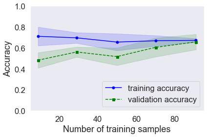

```
Eksimaatriks, kus telgedel on ennustatavad (y-telg) ja ennustatud(x-telg) väärtused:
Test: [84, 77, 86, 89, 81, 48, 11, 100, 79, 64, 100, 100, 94, 91, 84, 79, 86, 92, 58, 62, 88, 14, 70, 86, 60, 83, 78, 83, 71, 97, 78, 71, 55, 68, 85, 100, 81, 95, 79]
Pred: [80, 86, 86, 86, 80, 100, 100, 86, 80, 80, 100, 0, 86, 86, 86, 86, 80, 86, 86, 86, 86, 100, 86, 86, 86, 80, 86, 80, 80, 86, 86, 86, 86, 86, 86, 100, 80, 86, 80]


CV täpsused:  [0.7826087  0.60869565 0.56521739 0.60869565 0.68181818]
CV keskmine täpsus: 0.649 +/- 0.076
```

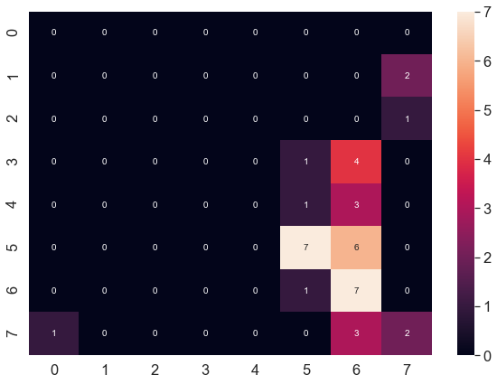

```python
pipe_lr = Pipeline([('std', StandardScaler()),
                    ('skb', SelectKBest()),
                    ('tree', DecisionTreeClassifier())])

param_grid = [{
               'skb__k': [1, 2, 3, 4, 5, 6, 7, 'all'],
               'tree__splitter': ["best"],
               'tree__max_depth': [1, 2, 3, 4, 5, 10, 100],
               'tree__criterion': ["gini", "entropy"]
              }]

gs = GridSearchCV(estimator=pipe_lr,
                  param_grid=param_grid,
                  scoring=my_scorer,
                  cv=5,
                  n_jobs=-1)

gs = gs.fit(X_train, y_train)

print('Täpsus: ', gs.best_score_)
print(gs.best_params_)
pipe_lr = gs.best_estimator_
print('K_means klastrite olulisused:', pipe_lr.named_steps['tree'].feature_importances_)

validation_curve(my_scorer)
printConfusionMatrix()
printScore(my_scorer)
```

KNeighboursRegressor - tekitab klastrid ja annab väärtuse vastavalt sellest, kus sisendpunkt võrreldes teiste punktidega on n dimensionaalses ruumis kus siis n-neighbours on väärtus, mitut teist punkti vaadatakse.

```
Täpsus:  0.5533596837944664
{'knr__algorithm': 'auto', 'knr__leaf_size': 1, 'knr__n_jobs': 1, 'knr__n_neighbors': 5, 'knr__p': 2}
```

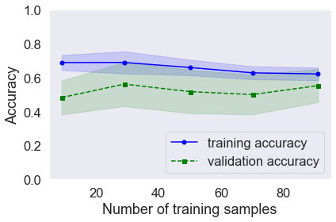

```
Eksimaatriks, kus telgedel on ennustatavad (y-telg) ja ennustatud(x-telg) väärtused:
Test: [84, 77, 86, 89, 81, 48, 11, 100, 79, 64, 100, 100, 94, 91, 84, 79, 86, 92, 58, 62, 88, 14, 70, 86, 60, 83, 78, 83, 71, 97, 78, 71, 55, 68, 85, 100, 81, 95, 79]
Pred: [77, 87, 84, 71, 80, 87, 63, 76, 78, 81, 86, 45, 58, 90, 56, 87, 78, 83, 84, 83, 75, 63, 82, 87, 86, 78, 86, 78, 78, 73, 79, 79, 77, 80, 85, 76, 78, 86, 79]


CV täpsused:  [0.69565217 0.52173913 0.47826087 0.43478261 0.63636364]
CV keskmine täpsus: 0.553 +/- 0.098
```

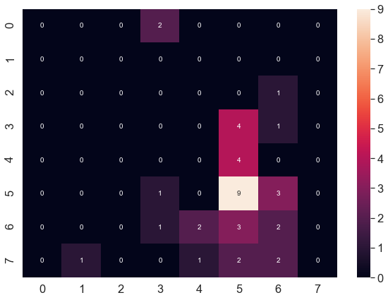

```python
pipe_lr = Pipeline([('sc1', StandardScaler()),
                    ('knr', KNeighborsRegressor())])

param_grid = [{
               'knr__algorithm': ["auto", "ball_tree", "kd_tree", "brute"],
               'knr__leaf_size': [1, 5],
               'knr__n_jobs': [1, 5],
               'knr__n_neighbors': [1, 2, 3, 4, 5],
               'knr__p': [1, 2]
              }]

gs = GridSearchCV(estimator=pipe_lr,
                  param_grid=param_grid,
                  scoring=my_scorer,
                  cv=5,
                  n_jobs=-1)

gs = gs.fit(X_train, y_train)

print('Täpsus: ', gs.best_score_)
print(gs.best_params_)

pipe_lr = gs.best_estimator_

validation_curve(my_scorer)
printConfusionMatrix()
printScore(my_scorer)
```

Perceptron - närvivõrk - teeb 48 klassi millest ka 48 neuronit kus igal on omavektoritel omad kaalud

```
Täpsus:  0.5877470355731226
{'pca__n_components': 4, 'per__max_iter': 100, 'per__penalty': 'l1'}
Perceptroni poolt tehtud klasside arv: 48
```

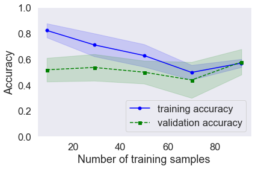

```
Eksimaatriks, kus telgedel on ennustatavad (y-telg) ja ennustatud(x-telg) väärtused:
Test: [84, 77, 86, 89, 81, 48, 11, 100, 79, 64, 100, 100, 94, 91, 84, 79, 86, 92, 58, 62, 88, 14, 70, 86, 60, 83, 78, 83, 71, 97, 78, 71, 55, 68, 85, 100, 81, 95, 79]
Pred: [78, 91, 40, 94, 78, 94, 94, 97, 78, 78, 89, 94, 94, 86, 94, 91, 78, 77, 77, 94, 94, 94, 77, 77, 40, 78, 79, 78, 78, 40, 77, 77, 94, 77, 59, 94, 78, 94, 78]


CV täpsused:  [0.60869565 0.73913043 0.56521739 0.43478261 0.59090909]
CV keskmine täpsus: 0.588 +/- 0.097
```

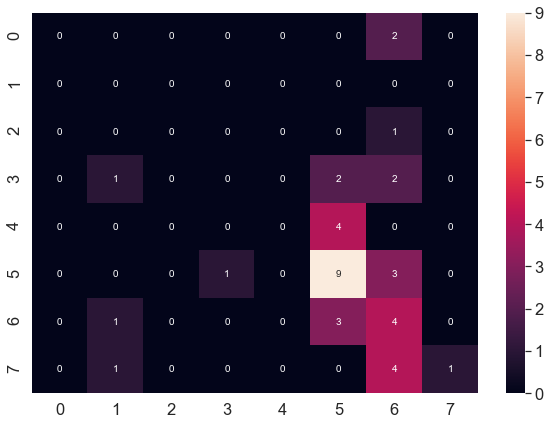

```python
pipe_lr = Pipeline([('sc', StandardScaler()),
                    ('pca', PCA()),
                    ('per', Perceptron())])

param_grid = [{'pca__n_components': [1, 2, 3, 4, 5],
               'per__max_iter': [10, 100, 500, 1000],
               'per__penalty': ["l2", "l1", "elasticnet", "none"]
              }]

gs = GridSearchCV(estimator=pipe_lr,
                  param_grid=param_grid,
                  scoring=my_scorer,
                  cv=5,
                  n_jobs=-1)

gs = gs.fit(X_train, y_train)

print('Täpsus: ', gs.best_score_)
print(gs.best_params_)
pipe_lr = gs.best_estimator_
print('Perceptroni poolt tehtud klasside arv:', len(pipe_lr.named_steps['per'].classes_))

validation_curve(my_scorer)
printConfusionMatrix()
printScore(my_scorer)
```

Ada - Teeb hunnikutes estimatoreid ehk siis teisisõnu baasmudeleid, mis on teised regressioonid ning kontseptuaalselt kujutab boosting endas seda, et nõrgemaid mudeleid aidatakse järgi

```
Täpsus:  0.5786561264822134
{'ada__base_estimator': GradientBoostingRegressor(alpha=0.9, ccp_alpha=0.0, criterion='friedman_mse',
                          init=None, learning_rate=0.1, loss='ls', max_depth=3,
                          max_features=None, max_leaf_nodes=None,
                          min_impurity_decrease=0.0, min_impurity_split=None,
                          min_samples_leaf=1, min_samples_split=2,
                          min_weight_fraction_leaf=0.0, n_estimators=100,
                          n_iter_no_change=None, presort='deprecated',
                          random_state=None, subsample=1.0, tol=0.0001,
                          validation_fraction=0.1, verbose=0, warm_start=False), 'ada__loss': 'square', 'ada__n_estimators': 10, 'pca__n_components': 1}
[3.26343912 3.4636791  2.87510664 2.94116945 3.99323328 3.4803946
 3.23132525 3.39202301 3.43725456 3.42963904]
```

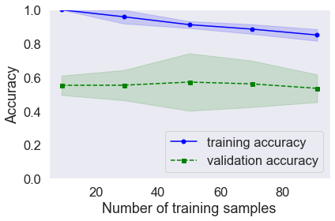

```
Eksimaatriks, kus telgedel on ennustatavad (y-telg) ja ennustatud(x-telg) väärtused:
Test: [84, 77, 86, 89, 81, 48, 11, 100, 79, 64, 100, 100, 94, 91, 84, 79, 86, 92, 58, 62, 88, 14, 70, 86, 60, 83, 78, 83, 71, 97, 78, 71, 55, 68, 85, 100, 81, 95, 79]
Pred: [82, 93, 92, 89, 82, 71, 99, 76, 82, 81, 72, 99, 89, 93, 71, 93, 82, 84, 83, 93, 71, 98, 92, 83, 93, 82, 87, 82, 83, 90, 83, 83, 91, 84, 87, 82, 82, 90, 81]


CV täpsused:  [0.73913043 0.52173913 0.52173913 0.47826087 0.5       ]
CV keskmine täpsus: 0.552 +/- 0.095
```

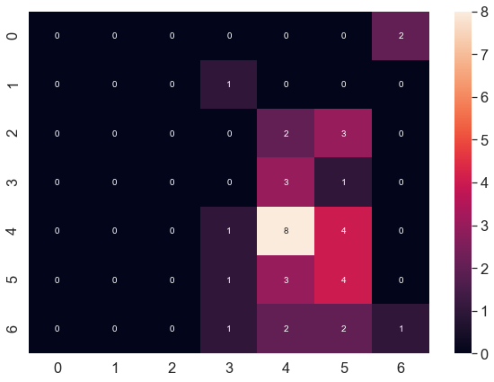

```python
pipe_lr = Pipeline([('sc1', StandardScaler()),
                    ('pca', PCA()),
                    ('ada', AdaBoostRegressor())])

base_models = [ExtraTreesRegressor(),
               RandomForestRegressor(),
               DecisionTreeRegressor(),
               GradientBoostingRegressor()]

param_grid = [{
               'pca__n_components': [1, 2],
               'ada__n_estimators': [1, 5, 10],
               'ada__loss': ["linear", "square", "exponential"],
               'ada__base_estimator': base_models
              }]

gs = GridSearchCV(estimator=pipe_lr,
                  param_grid=param_grid,
                  scoring=my_scorer,
                  cv=5,
                  n_jobs=-1)

gs = gs.fit(X_train, y_train)

print('Täpsus: ', gs.best_score_)
print(gs.best_params_)
pipe_lr = gs.best_estimator_
print(pipe_lr.named_steps['ada'].estimator_weights_)

validation_curve(my_scorer)
printConfusionMatrix()
printScore(my_scorer)
```

Lineaarne regressioon - pidev, sellest ka 1 omavektor millega proovib ennustada seda, kus väärtus arvteljel on.

```
Täpsus:  0.51699604743083
{'lgr__copy_X': True, 'lgr__fit_intercept': True, 'lgr__n_jobs': 1, 'lgr__normalize': True, 'pca__n_components': 3}
PCA omavektorite olulisused: [ 2.25076856  2.40777445 -3.02265046]
```

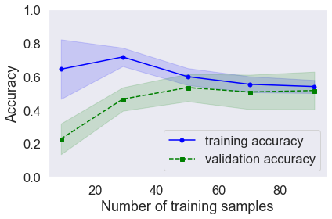

```
Eksimaatriks, kus telgedel on ennustatavad (y-telg) ja ennustatud(x-telg) väärtused:
Test: [84, 77, 86, 89, 81, 48, 11, 100, 79, 64, 100, 100, 94, 91, 84, 79, 86, 92, 58, 62, 88, 14, 70, 86, 60, 83, 78, 83, 71, 97, 78, 71, 55, 68, 85, 100, 81, 95, 79]
Pred: [90, 78, 73, 73, 87, 72, 70, 75, 82, 81, 73, 70, 71, 79, 71, 77, 81, 79, 81, 74, 73, 70, 77, 81, 77, 87, 76, 82, 77, 73, 76, 79, 73, 81, 77, 72, 78, 75, 83]


CV täpsused:  [0.73913043 0.47826087 0.43478261 0.47826087 0.45454545]
CV keskmine täpsus: 0.517 +/- 0.112
```

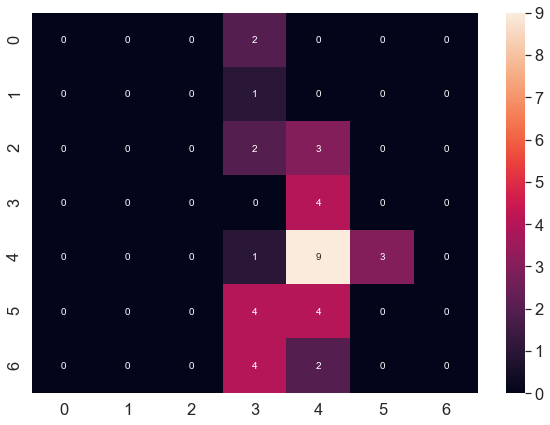

```python
pipe_lr = Pipeline([('sc1', StandardScaler()),
                    ('pca', PCA()),
                    ('lgr', LinearRegression())])

param_grid = [{
               'pca__n_components': [1, 2, 3, 4, 5, 6],
               'lgr__normalize': [True, False],
               'lgr__n_jobs': [1, 5, 10, 25, 50, 100, 250, 1000, -1],
               'lgr__fit_intercept': [True, False],
               'lgr__copy_X': [True, False]
              }]

gs = GridSearchCV(estimator=pipe_lr,
                  param_grid=param_grid,
                  scoring=my_scorer,
                  cv=5,
                  n_jobs=-1)

gs = gs.fit(X_train, y_train)

print('Täpsus: ', gs.best_score_)
print(gs.best_params_)
pipe_lr = gs.best_estimator_
print('PCA omavektorite olulisused:', pipe_lr.named_steps['lgr'].coef_)

validation_curve(my_scorer)
printConfusionMatrix()
printScore(my_scorer)
```

Lasso - Regulisaator - lineaar regressioonil baseeruv kus väärtuseid kahandatakse tsentraalse keskpunkti suunas

```
Täpsus:  0.5351778656126482
{'lasso__copy_X': True, 'lasso__fit_intercept': True, 'lasso__max_iter': 10, 'lasso__normalize': False, 'lasso__precompute': True}
[ 0.          0.          0.82803679 -0.13006014  2.46313965  0.67693938
  2.13637026]
```

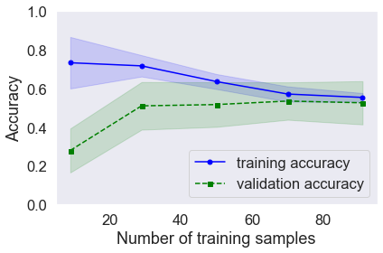

```
Eksimaatriks, kus telgedel on ennustatavad (y-telg) ja ennustatud(x-telg) väärtused:
Test: [84, 77, 86, 89, 81, 48, 11, 100, 79, 64, 100, 100, 94, 91, 84, 79, 86, 92, 58, 62, 88, 14, 70, 86, 60, 83, 78, 83, 71, 97, 78, 71, 55, 68, 85, 100, 81, 95, 79]
Pred: [86, 78, 75, 74, 85, 71, 70, 76, 82, 81, 72, 71, 73, 78, 71, 78, 82, 79, 81, 76, 73, 70, 78, 80, 77, 83, 79, 82, 79, 73, 78, 79, 75, 80, 78, 72, 80, 75, 82]


CV täpsused:  [0.73913043 0.43478261 0.52173913 0.43478261 0.54545455]
CV keskmine täpsus: 0.535 +/- 0.111
```

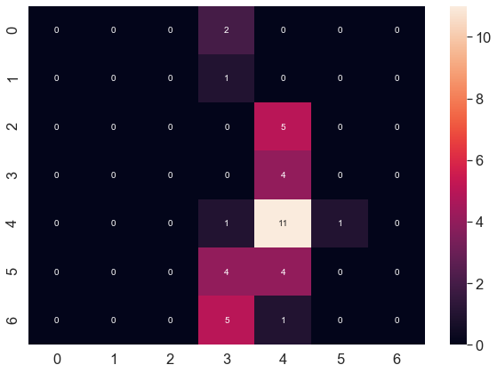

```python
pipe_lr = Pipeline([('sc1', StandardScaler()),
#                     ('pca', PCA()),
                    ('lasso', Lasso())
                   ])


param_grid = [{
#                'pca__n_components': [1, 2],
               'lasso__normalize': [True, False],
               'lasso__max_iter': [1, 5, 10, 25, 50, 100, 250],
               'lasso__precompute': [True, False],
               'lasso__copy_X': [True, False],
               'lasso__fit_intercept': [True, False],
              }]

gs = GridSearchCV(estimator=pipe_lr,
                  param_grid=param_grid,
                  scoring=my_scorer,
                  cv=5,
                  n_jobs=-1)

gs = gs.fit(X_train, y_train)

print('Täpsus: ', gs.best_score_)
print(gs.best_params_)
pipe_lr = gs.best_estimator_
print(pipe_lr.named_steps['lasso'].coef_)

validation_curve(my_scorer)
printConfusionMatrix()
printScore(my_scorer)
```

Logistiline regressioon - 48 klassi, sellest ka 48 omavektorit millega proovib ennustada seda, millisesse klassi ta kõige tõenäolisemalt satub.

```
Täpsus:  0.684189723320158
{'lgr__max_iter': 100, 'lgr__penalty': 'none', 'lgr__solver': 'sag', 'pca__n_components': 4}
Regressiooni poolt tekitatud klasside arv: 48
```

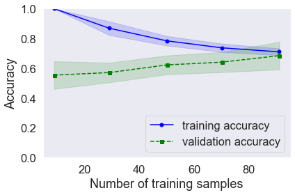

```
Eksimaatriks, kus telgedel on ennustatavad (y-telg) ja ennustatud(x-telg) väärtused:
Test: [84, 77, 86, 89, 81, 48, 11, 100, 79, 64, 100, 100, 94, 91, 84, 79, 86, 92, 58, 62, 88, 14, 70, 86, 60, 83, 78, 83, 71, 97, 78, 71, 55, 68, 85, 100, 81, 95, 79]
Pred: [79, 82, 86, 100, 79, 100, 100, 67, 79, 80, 100, 100, 100, 86, 100, 82, 79, 80, 86, 86, 100, 100, 86, 86, 86, 80, 82, 80, 80, 100, 80, 86, 61, 86, 82, 100, 79, 100, 80]


CV täpsused:  [0.82608696 0.73913043 0.60869565 0.56521739 0.68181818]
CV keskmine täpsus: 0.684 +/- 0.093
```

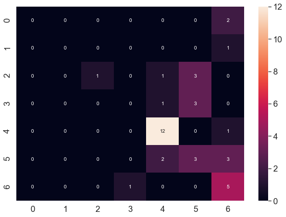

```python
pipe_lr = Pipeline([('sc1', StandardScaler()),
                    ('pca', PCA()),
                    ('lgr', LogisticRegression())])

param_grid = [{'pca__n_components': [1, 2, 3, 4, 5],
               'lgr__max_iter': [10, 100],
               'lgr__solver': ["newton-cg", "lbfgs", "sag", "saga"],
               'lgr__penalty': ["l2", "none"]
              }]

gs = GridSearchCV(estimator=pipe_lr,
                  param_grid=param_grid,
                  scoring=my_scorer,
                  cv=5,
                  n_jobs=-1)

gs = gs.fit(X_train, y_train)

print('Täpsus: ', gs.best_score_)
print(gs.best_params_)
pipe_lr = gs.best_estimator_

print('Regressiooni poolt tekitatud klasside arv:', len(pipe_lr.named_steps['lgr'].classes_))
# print('PCA omavektorite olulisuse:', pipe_lr.named_steps['lgr'].coef_)

validation_curve(my_scorer)
printConfusionMatrix()
printScore(my_scorer)
```

Nüüd proovib ilma PCA'ta Lassot, et saada kätte atribuutide olulisused

```python
pipe_lr = Pipeline([('sc1', StandardScaler()),
                    ('lasso', Lasso())
                   ])


param_grid = [{
#                'pca__n_components': [1, 2],
               'lasso__normalize': [True, False],
               'lasso__max_iter': [1, 5, 10, 25, 50, 100, 250],
               'lasso__precompute': [True, False],
               'lasso__copy_X': [True, False],
               'lasso__fit_intercept': [True, False],
              }]

gs = GridSearchCV(estimator=pipe_lr,
                  param_grid=param_grid,
                  scoring=my_scorer,
                  cv=5,
                  n_jobs=-1)

gs = gs.fit(X_train, y_train)

print('Täpsus: ', gs.best_score_)
print(gs.best_params_)
pipe_lr = gs.best_estimator_
printScore(my_scorer)

print("Atribuutide olulisused: ")
_ = [print(f"{columns2[x]}: {pipe_lr.named_steps['lasso'].coef_[x]}") for x in range(len(pipe_lr.named_steps['lasso'].coef_))]
```

```
Täpsus:  0.5351778656126482
{'lasso__copy_X': True, 'lasso__fit_intercept': True, 'lasso__max_iter': 10, 'lasso__normalize': False, 'lasso__precompute': True}

CV täpsused:  [0.73913043 0.43478261 0.52173913 0.43478261 0.54545455]
CV keskmine täpsus: 0.535 +/- 0.111
Atribuutide olulisused:
totalCommits: 0.0
totalTestsRan: 0.0
totalTestsPassed: 0.828036794062407
totalDiagnosticErrors: -0.130060144702275
differentSlugs: 2.4631396501620815
differentCourses: 0.6769393826587974
commitsStyleOK: 2.136370264099352
```

Olulisteks faktoriteks kujunesid:

- Erinevate ülesannete lahendamiste arv
- Koodi stiil
- Sealsetest testidest läbi saamiste arv

Mudelite tulemused olid järgmised:

```
* StandardScaler(), PCA(), LinearRegression() CV keskmine täpsus: 0.517 +/- 0.112
* StandardScaler(), KNeighborsRegressor() CV keskmine täpsus: 0.553 +/- 0.098
* StandardScaler(), PCA(), Perceptron() CV keskmine täpsus: 0.588 +/- 0.097
* StandardScaler(), PCA(), AdaBoostRegressor() CV keskmine täpsus: 0.552 +/- 0.095
* StandardScaler(), Lasso() CV keskmine täpsus: 0.535 +/- 0.111
* StandardScaler(), SelectKBest(), DecisionTreeClassifier() CV keskmine täpsus: 0.649 +/- 0.076
* StandardScaler(), PCA(), LogisticRegression() CV keskmine täpsus: 0.684 +/- 0.093
```

Kokkuvõte:

Tudengeid andis jagada kahte klastrisse nii, et siluetti skoor oli 0.56, mis oli parim skoor võimalike klastrite arvu poolest.

Tagant järele mõeldes on see ka loogiline, sest tudengid lahendavad ülesandeid väga erinevalt ning nende tudengite võimed on samuti erinevad.

Klasterdamise kokkuvõtteks võib öelda nii palju, et tudengite õppeedukused ja selle tulemuse saavutamiseks valitud meetodid on selgelt eristatavad üksteisest. Ning on ka näha, et üks teatud õppeviis on laiemalt levinum kui ülejäänud.

Pideva muutuja ennustamisel valisin pidevaks muutujaks averageGrade'i. Parim mudel selle ennustamiseks oli pipeline, mis koosnes järgnevatest komponentidest:

- StandardScaler()
- PCA(n_components=4)
- LogisticRegression(max_iter=100, penalty='none', solver='sag')

Ning mis koondus ilusti ning andis tulemuseks 0.684 +/- 0.093. Kui järgmine aasta seda faili uuesti jooksutada, siis peaks see tulemus tõusma, kuna siis on juba rohkem andmeid tudengite testimiste kohta.

Erinevate ülesannete ka tõstab keskmist tulemust suuresti.

Ärilised väljundid:

Testimistes, kus pole stiilivigu on tugevas seoses kõrge keskmise hindega.

Mis puudututab õppeedukust, siis diagnostiliste arv on vastupidises seoses hea tulemuse saamisega, mis tähendab, et peaks rõhku panema varakult juba hea koodi stiili omandamisele.

Selle mudeliga saab ennustada testimise tulemuste pealt tudengi õppeedukust. Andmebaasis eksisteerivad veel lisaks gümnaasiumi tudengite andmed. Mudelit, mis on treenitud TalTech'i tudengite andmete peal saab kasutada gümnaasiumi õpilaste õppeedukuse ennustamiseks, et teada, kui suure tõenäosusega saab tudeng ülikoolis hakkama.